# Chl-a Decomposition

Dunnigan, S

7/19/2022

## Background

Recreating Figure 3 from Cloern and Jassby 2010. Blue lines are monthly series of Chl-*a* concentration; red bars are annual components $y$ showing deviation from 1; purple lines are residual components $\epsilon$ showing deviation from 1, and green bars are standard seasonal patterns $m$ showing deviations from 1. Based on Equation 4 from Cloern and Jassby 2010:

$$c_{ij}=Cy_im_j\epsilon_{ij}$$
Where $c_{ij}$ is chlorophyll concentration in year $i$($i=1,...,N$) and month $j$($j=1,...12$); *C* is the long-term mean of the series; $y_i$ is the annual effect in the *i*th year; $m_j$ is the seasonal (monthly) effect in the *j*th month; and $\epsilon_{ij}$ is the residual.

- If $y_i$ >1, indicates a year with above-average mean Chl-*a*.
- If $m_j$ >1, indicates a mean monthly Chl-*a* greater than the annual mean.
- If $\epsilon_{ij}$ >1, indicates an observation greater than the expected value for that month and year.

### Pine Island

[figure not shown]

### San Sebastian

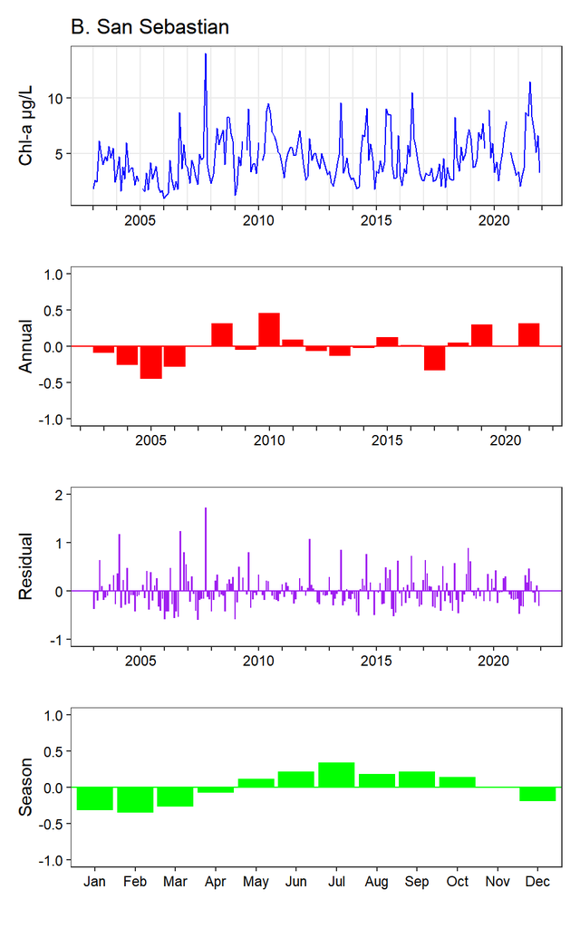

### Fort Matanzas

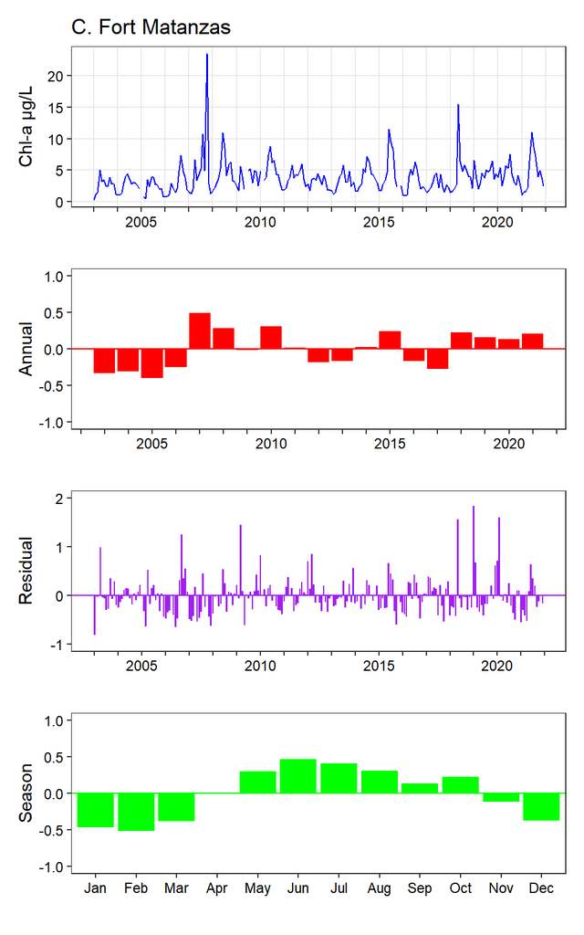

### Pellicer Creek

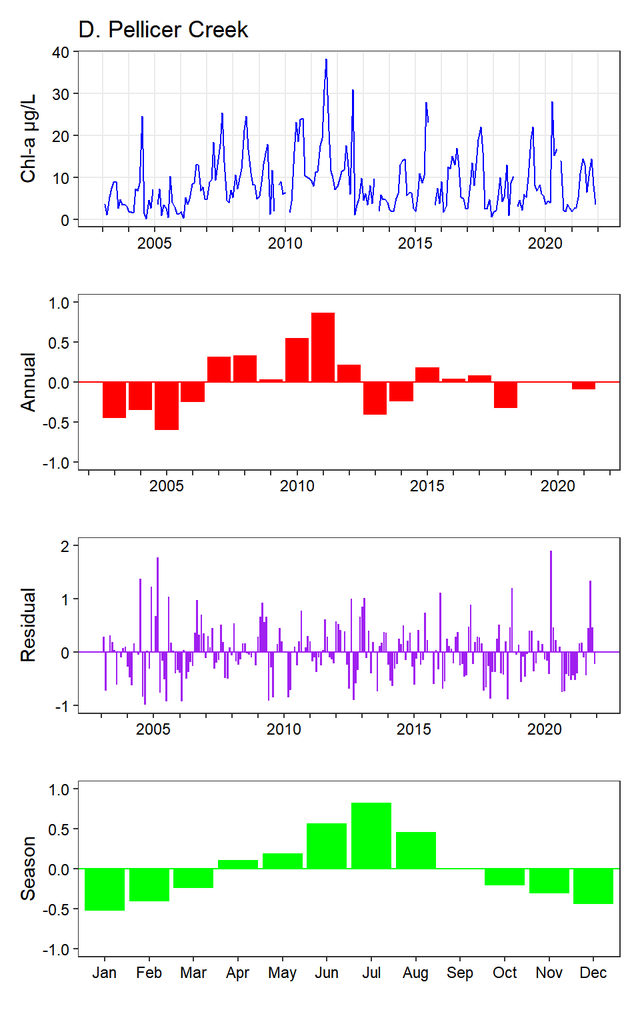

## Variability of phytoplankton patterns

For individual Chl-*a* series, the standard deviations of $y$($SD_y$) and $m$($SD_m$) are measures of annual and seasonal variability, respectively. In Cloern and Jassby 2010, the 84 sites in their study typically fell within the range of 0.2-0.4 for $y$ and 0.1-0.6 for $m$.

Standard Deviations of variability at all four GTMNERR SWMP stations

| site | SDy | SDm | SDe |
| --- | --- | --- | --- |
| PI | 0.198 | 0.330 | 0.349 |
| SS | 0.232 | 0.225 | 0.349 |
| FM | 0.251 | 0.345 | 0.419 |
| PC | 0.359 | 0.419 | 0.504 |